# AllLife Bank Personal Loan Campaign - Logistic Regression & Decision Tree

## Background and Context

AllLife Bank is a US bank that has a growing customer base. The majority of these customers are liability customers (depositors) with varying sizes of deposits. The number of customers who are also borrowers (asset customers) is quite small, and the bank is interested in expanding this base rapidly to bring in more loan business and in the process, earn more through the interest on loans. In particular, the management wants to explore ways of converting its liability customers to personal loan customers (while retaining them as depositors).

A campaign that the bank ran last year for liability customers showed a healthy conversion rate of over 9% success. This has encouraged the retail marketing department to devise campaigns with better target marketing to increase the success ratio.

You as a Data scientist at AllLife bank have to build a model that will help the marketing department to identify the potential customers who have a higher probability of purchasing the loan.

## Objective

- To predict whether a liability customer will buy a personal loan or not.
- Which variables are most significant.
- Which segment of customers should be targeted more.

## Data Dictionary

- ID: Customer ID
- Age: Customer’s age in completed years
- Experience: #years of professional experience
- Income: Annual income of the customer (in thousand dollars)
- ZIP Code: Home Address ZIP code.
- Family: the Family size of the customer
- CCAvg: Average spending on credit cards per month (in thousand dollars)
- Education: Education Level. 1: Undergrad; 2: Graduate;3: Advanced/Professional
- Mortgage: Value of house mortgage if any. (in thousand dollars)
- Personal_Loan: Did this customer accept the personal loan offered in the last campaign?
- Securities_Account: Does the customer have securities account with the bank?
- CD_Account: Does the customer have a certificate of deposit (CD) account with the bank?
- Online: Do customers use internet banking facilities?
- CreditCard: Does the customer use a credit card issued by any other Bank (excluding All life Bank)?

# Let's start coding!

### Installing uszipcode library

```python
%%capture
#discard the output of this cell

# Fix mentioned in comment - https://github.com/MacHu-GWU/uszipcode-project/issues/48#issuecomment-805765141
# needs to be applied manually, else from uszipcode import SearchEngine will throw error
!pip install SQLAlchemy<1.4.0
!pip install uszipcode
!pip install mlxtend
```

### Loading necessary libraries

```python
import pandas as pd
import numpy as np
import matplotlib.pyplot as plt
%matplotlib inline

import seaborn as sns

sns.set()

import warnings

warnings.filterwarnings("ignore")

# Removes the limit for the number of displayed columns
pd.set_option("display.max_columns", None)
# Sets the limit for the number of displayed rows
pd.set_option("display.max_rows", 200)

# To build linear model for prediction
from sklearn.linear_model import LinearRegression

# To check model performance
from sklearn.metrics import mean_squared_error, r2_score, mean_absolute_error

# to split the data into test and train set
from sklearn.model_selection import train_test_split

# import the zipcode library
from uszipcode import SearchEngine


# Libraries to build Logistic regression
from sklearn.linear_model import LogisticRegression

# Libraries to build decision tree classifier
from sklearn.tree import DecisionTreeClassifier
from sklearn import tree

# To tune different models
from sklearn.model_selection import GridSearchCV

# To get diferent metric scores
from sklearn.metrics import (
    f1_score,
    accuracy_score,
    recall_score,
    precision_score,
    confusion_matrix,
    plot_confusion_matrix,
    make_scorer,
    roc_auc_score,
    precision_recall_curve,
    roc_curve
)
```

### Load the data for analysis

```python
data=pd.read_csv('Loan_Modelling.csv')
df = data.copy()
```

### Shape of the data

```python
print("There are "+ str(df.shape[0]) +" rows and "+ str(df.shape[1])+" columns")
```

```
There are 5000 rows and 14 columns
```

### Let's view a sample of the dataset.

```python
np.random.seed(2)  # To get the same random results every time
df.sample(10)
```

|  | ID | Age | Experience | Income | ZIPCode | Family | CCAvg | Education | Mortgage | Personal_Loan | Securities_Account | CD_Account | Online | CreditCard |
| --- | --- | --- | --- | --- | --- | --- | --- | --- | --- | --- | --- | --- | --- | --- |
| 3566 | 3567 | 57 | 33 | 80 | 92064 | 2 | 2.8 | 1 | 0 | 0 | 0 | 0 | 1 | 1 |
| 4252 | 4253 | 54 | 29 | 81 | 91107 | 1 | 0.1 | 3 | 0 | 0 | 0 | 0 | 0 | 0 |
| 1918 | 1919 | 39 | 9 | 118 | 93555 | 2 | 6.0 | 3 | 246 | 1 | 0 | 1 | 1 | 1 |
| 4111 | 4112 | 43 | 17 | 21 | 95351 | 3 | 1.5 | 1 | 0 | 0 | 0 | 0 | 0 | 0 |
| 1471 | 1472 | 52 | 26 | 180 | 94305 | 1 | 1.0 | 1 | 0 | 0 | 0 | 0 | 1 | 1 |
| 929 | 930 | 55 | 30 | 22 | 92121 | 1 | 1.5 | 2 | 91 | 0 | 0 | 0 | 0 | 1 |
| 1916 | 1917 | 57 | 32 | 64 | 95138 | 3 | 1.6 | 3 | 0 | 0 | 0 | 0 | 1 | 0 |
| 3995 | 3996 | 53 | 28 | 34 | 92697 | 2 | 0.6 | 3 | 0 | 0 | 0 | 0 | 1 | 1 |
| 1130 | 1131 | 58 | 32 | 191 | 94402 | 1 | 2.9 | 1 | 0 | 0 | 0 | 0 | 0 | 0 |
| 1723 | 1724 | 39 | 15 | 55 | 95821 | 1 | 1.5 | 3 | 0 | 0 | 0 | 0 | 1 | 0 |

### Duplicate values in the data

```python
df.duplicated().sum()
```

```
0
```

### Missing values (count) in the data.

```python
df.isnull().sum()
```

```
ID                    0
Age                   0
Experience            0
Income                0
ZIPCode               0
Family                0
CCAvg                 0
Education             0
Mortgage              0
Personal_Loan         0
Securities_Account    0
CD_Account            0
Online                0
CreditCard            0
dtype: int64
```

### Unique values (count) in the data.

```python
df.nunique()
```

```
ID                    5000
Age                     45
Experience              47
Income                 162
ZIPCode                467
Family                   4
CCAvg                  108
Education                3
Mortgage               347
Personal_Loan            2
Securities_Account       2
CD_Account               2
Online                   2
CreditCard               2
dtype: int64
```

### Data types of the columns in the dataset.

```python
df.info()
```

```
<class 'pandas.core.frame.DataFrame'>
RangeIndex: 5000 entries, 0 to 4999
Data columns (total 14 columns):
 #   Column              Non-Null Count  Dtype
---  ------              --------------  -----
 0   ID                  5000 non-null   int64
 1   Age                 5000 non-null   int64
 2   Experience          5000 non-null   int64
 3   Income              5000 non-null   int64
 4   ZIPCode             5000 non-null   int64
 5   Family              5000 non-null   int64
 6   CCAvg               5000 non-null   float64
 7   Education           5000 non-null   int64
 8   Mortgage            5000 non-null   int64
 9   Personal_Loan       5000 non-null   int64
 10  Securities_Account  5000 non-null   int64
 11  CD_Account          5000 non-null   int64
 12  Online              5000 non-null   int64
 13  CreditCard          5000 non-null   int64
dtypes: float64(1), int64(13)
memory usage: 547.0 KB
```

### Summary of the dataset

```python
df.describe().T
```

|  | count | mean | std | min | 25% | 50% | 75% | max |
| --- | --- | --- | --- | --- | --- | --- | --- | --- |
| ID | 5000.0 | 2500.500000 | 1443.520003 | 1.0 | 1250.75 | 2500.5 | 3750.25 | 5000.0 |
| Age | 5000.0 | 45.338400 | 11.463166 | 23.0 | 35.00 | 45.0 | 55.00 | 67.0 |
| Experience | 5000.0 | 20.104600 | 11.467954 | -3.0 | 10.00 | 20.0 | 30.00 | 43.0 |
| Income | 5000.0 | 73.774200 | 46.033729 | 8.0 | 39.00 | 64.0 | 98.00 | 224.0 |
| ZIPCode | 5000.0 | 93169.257000 | 1759.455086 | 90005.0 | 91911.00 | 93437.0 | 94608.00 | 96651.0 |
| Family | 5000.0 | 2.396400 | 1.147663 | 1.0 | 1.00 | 2.0 | 3.00 | 4.0 |
| CCAvg | 5000.0 | 1.937938 | 1.747659 | 0.0 | 0.70 | 1.5 | 2.50 | 10.0 |
| Education | 5000.0 | 1.881000 | 0.839869 | 1.0 | 1.00 | 2.0 | 3.00 | 3.0 |
| Mortgage | 5000.0 | 56.498800 | 101.713802 | 0.0 | 0.00 | 0.0 | 101.00 | 635.0 |
| Personal_Loan | 5000.0 | 0.096000 | 0.294621 | 0.0 | 0.00 | 0.0 | 0.00 | 1.0 |
| Securities_Account | 5000.0 | 0.104400 | 0.305809 | 0.0 | 0.00 | 0.0 | 0.00 | 1.0 |
| CD_Account | 5000.0 | 0.060400 | 0.238250 | 0.0 | 0.00 | 0.0 | 0.00 | 1.0 |
| Online | 5000.0 | 0.596800 | 0.490589 | 0.0 | 0.00 | 1.0 | 1.00 | 1.0 |
| CreditCard | 5000.0 | 0.294000 | 0.455637 | 0.0 | 0.00 | 0.0 | 1.00 | 1.0 |

**Observation**

- There is no duplicate rows
- There is no missing values, but there are negative values in Experience field, this needs to be corrected.
- All fields are numerical datatype
- Education and ZIPCode have numerical values but there are categorical variable in nature
- Personal_Loan, Securities_Account, CD_Account, Online and CreditCard contains binary value - i.e either 0 or 1, this signifies that these fields are categorical in nature

## Data Preprocessing

### ID

ID column is a sequencial number assigned to each record, this doesn't add any value for analysis. Hence dropping of the column

```python
df.drop(['ID'],axis=1,inplace=True)
df.shape
```

```
(5000, 13)
```

### Experience

Experience column has negataive values, which can be considered as missing value

```python
print("Number of rows with negative values for Experience column "+ str(df[df['Experience']<0]['Experience'].count()))
```

```
Number of rows with negative values for Experience column 52
```

##### Lets analyze records for determing how to best treat these missing values

```python
df[df['Experience']==0].count()
```

```
Age                   66
Experience            66
Income                66
ZIPCode               66
Family                66
CCAvg                 66
Education             66
Mortgage              66
Personal_Loan         66
Securities_Account    66
CD_Account            66
Online                66
CreditCard            66
dtype: int64
```

```python
dfExpLessThanZero=df[df['Experience']<0]
pd.crosstab(dfExpLessThanZero.Experience,dfExpLessThanZero.Age)
```

| Age Experience | 23 | 24 | 25 | 26 | 28 | 29 |
| --- | --- | --- | --- | --- | --- | --- |
| -3 | 2 | 2 | 0 | 0 | 0 | 0 |
| -2 | 4 | 9 | 1 | 0 | 1 | 0 |
| -1 | 6 | 6 | 17 | 1 | 0 | 3 |

**Observation**

- 52 customers age between 23 - 29 have negative values

Years of professional experience plays a good role in terms of giving loan. Hence person might be 0 yrs experince if its value is less than 0, replacing all values of less than 0 to 0, instead of replacing it with mean.

```python
df.loc[df['Experience']<0,'Experience']=0
```

### ZIPCode

Detemining the county name from zipcode and creatig a new field in dataframe

```python
from uszipcode import SearchEngine
search = SearchEngine(simple_zipcode=True) # set simple_zipcode=False to use rich info database
```

```python
def findCounty(zipcode):
    location = search.by_zipcode(zipcode)
    if(location.county!=None):
        return location.county
    else:
        return np.nan

def findState(zipcode):
    location = search.by_zipcode(zipcode)
    if(location.state!=None):
        return location.state
    else:
        return np.nan
```

```python
df['County']=df['ZIPCode'].apply(findCounty)
df['State']=df['ZIPCode'].apply(findState)
```

#### Verifying there is no zipcode which is not mapped to county

```python
df[["County","State"]].isnull().sum()
```

```
County    34
State     34
dtype: int64
```

#### Finding out which zipcode didn't mapped correctly

```python
df[df['County'].isnull()]['ZIPCode'].unique()
```

```
array([92717, 93077, 92634, 96651])
```

```python
# Handling Missing values
df.loc[(df.ZIPCode == 92717),'County']='Orange County'
df.loc[(df.ZIPCode == 92717),'State']='CA'

df.loc[(df.ZIPCode == 93077),'County']='Ventura County'
df.loc[(df.ZIPCode == 93077),'State']='CA'

df.loc[(df.ZIPCode == 92634),'County']='Orange County'
df.loc[(df.ZIPCode == 92634),'State']='CA'

# Location fo zip code 96651 is not available
df.loc[(df.ZIPCode == 96651),'County']='UNKNOWN'
df.loc[(df.ZIPCode == 96651),'State']='UNKNOWN'
```

```python
#Find list of unique states
df['State'].unique()
```

```
array(['CA', 'UNKNOWN'], dtype=object)
```

```python
#Since all the records belongs to CA, dropping state column.
df.drop(['State'],axis=1,inplace=True)
```

### Checking whether there is any missing vlaue present

```python
df.isnull().sum()
```

```
Age                   0
Experience            0
Income                0
ZIPCode               0
Family                0
CCAvg                 0
Education             0
Mortgage              0
Personal_Loan         0
Securities_Account    0
CD_Account            0
Online                0
CreditCard            0
County                0
dtype: int64
```

### Checking datatypes information

```python
df.info()
```

```
<class 'pandas.core.frame.DataFrame'>
RangeIndex: 5000 entries, 0 to 4999
Data columns (total 14 columns):
 #   Column              Non-Null Count  Dtype
---  ------              --------------  -----
 0   Age                 5000 non-null   int64
 1   Experience          5000 non-null   int64
 2   Income              5000 non-null   int64
 3   ZIPCode             5000 non-null   int64
 4   Family              5000 non-null   int64
 5   CCAvg               5000 non-null   float64
 6   Education           5000 non-null   int64
 7   Mortgage            5000 non-null   int64
 8   Personal_Loan       5000 non-null   int64
 9   Securities_Account  5000 non-null   int64
 10  CD_Account          5000 non-null   int64
 11  Online              5000 non-null   int64
 12  CreditCard          5000 non-null   int64
 13  County              5000 non-null   object
dtypes: float64(1), int64(12), object(1)
memory usage: 547.0+ KB
```

#### Fixing DataType

'ZIPCode', County', 'Education','Family', 'Online', 'Personal_Loan', 'Securities_Account', 'CD_Account' and 'CreditCard' is categorical variable. Lets fix the datatype

```python
dfOriginalAfterPreProcessing=df.copy()
df['ZIPCode'] = df['ZIPCode'].astype('category')
df['County'] = df['County'].astype('category')
df['Family'] = df['Family'].astype('category')
df['Education'] = df['Education'].astype('category')
df['Online'] = df['Online'].astype('category')
df['Personal_Loan'] = df['Personal_Loan'].astype('category')
df['Securities_Account'] = df['Securities_Account'].astype('category')
df['CD_Account'] = df['CD_Account'].astype('category')
df['CreditCard'] = df['CreditCard'].astype('category')

##displaying dataframe details
df.info()
```

```
<class 'pandas.core.frame.DataFrame'>
RangeIndex: 5000 entries, 0 to 4999
Data columns (total 14 columns):
 #   Column              Non-Null Count  Dtype
---  ------              --------------  -----
 0   Age                 5000 non-null   int64
 1   Experience          5000 non-null   int64
 2   Income              5000 non-null   int64
 3   ZIPCode             5000 non-null   category
 4   Family              5000 non-null   category
 5   CCAvg               5000 non-null   float64
 6   Education           5000 non-null   category
 7   Mortgage            5000 non-null   int64
 8   Personal_Loan       5000 non-null   category
 9   Securities_Account  5000 non-null   category
 10  CD_Account          5000 non-null   category
 11  Online              5000 non-null   category
 12  CreditCard          5000 non-null   category
 13  County              5000 non-null   category
dtypes: category(9), float64(1), int64(4)
memory usage: 266.4 KB
```

### EDA & Data Visualization

```python
### Reuseable methods for drawing graphs


# Adds mean, median and mode line to the graph
def addGrapVLines(df, columnName,plot, title):
    plot.axvline(df[columnName].mean(), color='lightgreen', linestyle='-',linewidth=1)
    plot.axvline(df[columnName].median(), color='red', linestyle='--',linewidth=2)
    plot.axvline(df[columnName].mode()[0], color='orange', linestyle='-',linewidth=1)
    plot.legend({'Mean':df.mean(),'Median':df.median(),'Mode':df.mode()})
    plot.set(title=title)


# Draws three different types of graph (boxplot,distplot,violinplot) togather
def drawGraph(df,columnName):
    fig, axes = plt.subplots(ncols=3,figsize=(20, 5))


    plot=sns.boxplot(df[columnName],showmeans=True, data=df, ax=axes[0])
    addGrapVLines(df,columnName,plot,"df distribution and skewness for '"+columnName+"'")

    plot=sns.distplot(df[columnName],ax=axes[1],hist=True)
    addGrapVLines(df,columnName,plot," Variation in the df distribution for '"+columnName+"'")

    plot=sns.violinplot(df[columnName],showmeans=True,ax=axes[2])
    addGrapVLines(df,columnName,plot,"df Distribution for '"+columnName+"'")

# Draws Count plot for a particular column
def drawCountPlot(df,columnName,axes):
    dfPoints=df[columnName]
    indexCount = dfPoints.value_counts().index
    ax = sns.countplot(dfPoints, order=indexCount ,ax=axes)
    for patch in ax.patches:
        percentage = 100 * (patch.get_height()*1.0)/dfPoints.count()
        x = patch.get_x() + patch.get_width() / 2 - 0.05
        y = patch.get_y() + patch.get_height()
        ax.annotate("{percent:.2f}".format(percent=percentage)+"%", (x, y))

# Draws CatPlot plot for a particular column
def drawCatPlot(df,xColumnName,yColumnName, hueColumn,axes):
    sns.catplot(y=xColumnName,x=yColumnName,hue=hueColumn,kind="bar", data=df, ci='None',ax=axes);
    plt.close(2)

# Draws Box plot for a particular column
def drawBoxPlot(df,xColumnName,yColumnName,axes):
    sns.boxplot(df[xColumnName],df[yColumnName],ax=axes)
    plt.close(2)

# function to plot stacked bar chart
def stacked_barplot(data, predictor, target):
    count = data[predictor].nunique()
    sorter = data[target].value_counts().index[-1]
    tab1 = pd.crosstab(data[predictor], data[target], margins=True).sort_values(
        by=sorter, ascending=False
    )

    tab = pd.crosstab(data[predictor], data[target], normalize="index").sort_values(
        by=sorter, ascending=False
    )
    tab.plot(kind="bar", stacked=True, figsize=(20, 5))
    plt.legend(
        loc="lower left", frameon=False,
    )
    plt.legend(loc="upper left",bbox_to_anchor=(1, 1))
    plt.show()
```

#### Univariate Analysis

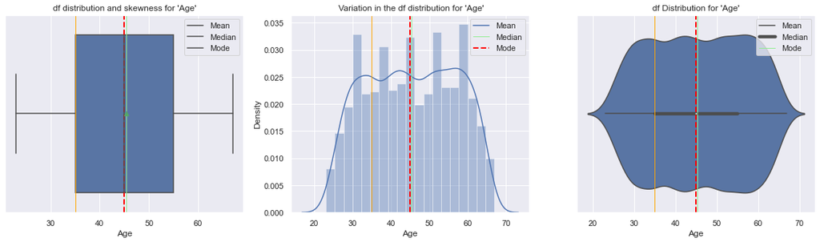

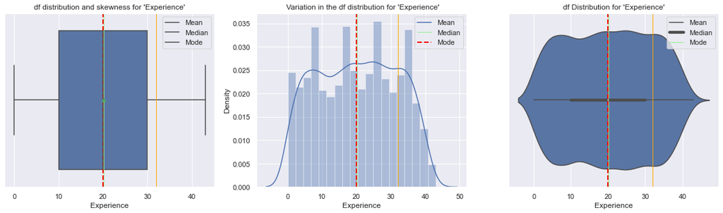

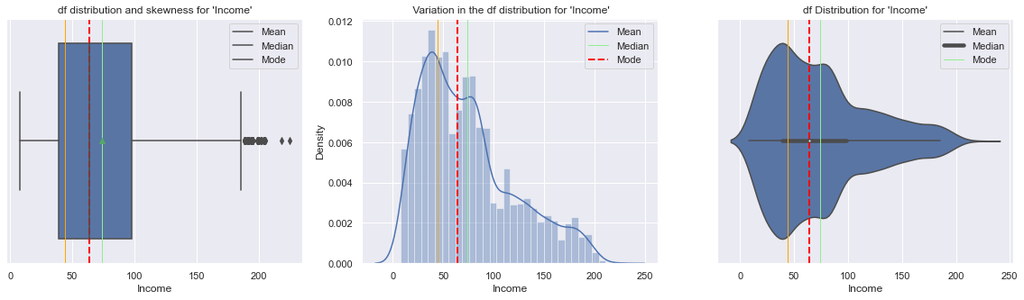

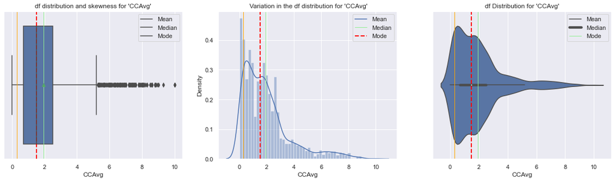

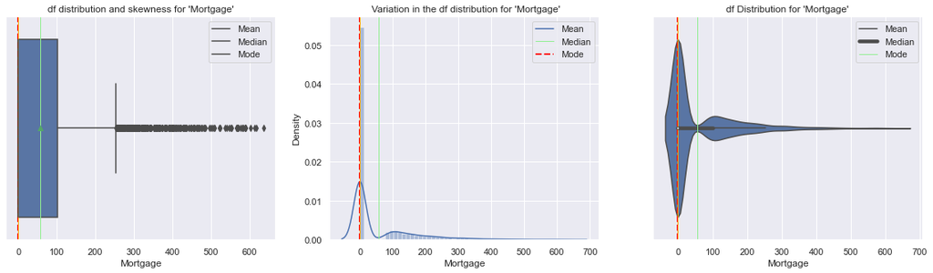

```python
drawGraph(df,'Age')
drawGraph(df,'Experience')
drawGraph(df,'Income')
drawGraph(df,'CCAvg')
drawGraph(df,'Mortgage')
```

**Observation**

- Income, CCAvg and Mortgage is right skewed
- Age and Experience has similar distribution of data

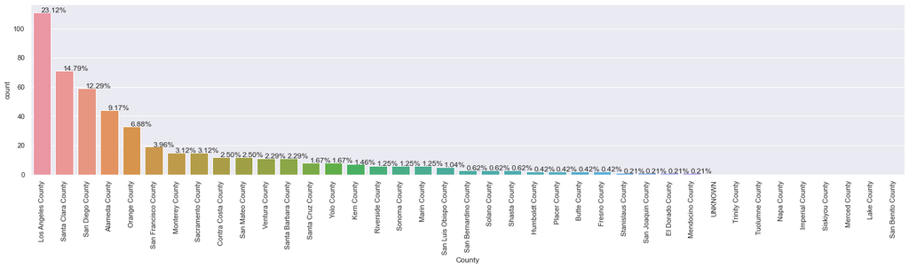

```python
fig, axes = plt.subplots(ncols=1,figsize=(25, 5))
plt.xticks(rotation=90)
drawCountPlot(df[df['Personal_Loan']==1],'County',axes);
plt.close(2)
```

```python
df.groupby(['County','Personal_Loan'])['Personal_Loan'].agg({'count'}).unstack().T
```

|  | County Personal_Loan | Alameda County | Butte County | Contra Costa County | El Dorado County | Fresno County | Humboldt County | Imperial County | Kern County | Lake County | Los Angeles County | Marin County | Mendocino County | Merced County | Monterey County | Napa County | Orange County | Placer County | Riverside County | Sacramento County | San Benito County | San Bernardino County | San Diego County | San Francisco County | San Joaquin County | San Luis Obispo County | San Mateo County | Santa Barbara County | Santa Clara County | … |
| --- | --- | --- | --- | --- | --- | --- | --- | --- | --- | --- | --- | --- | --- | --- | --- | --- | --- | --- | --- | --- | --- | --- | --- | --- | --- | --- | --- | --- | --- | --- |
| count | 0 | 456 | 17 | 73 | 16 | 24 | 30 | 3 | 47 | 4 | 984 | 48 | 7 | 4 | 113 | 3 | 333 | 22 | 50 | 169 | 14 | 98 | 509 | 238 | 12 | 28 | 192 | 143 | 492 | … |
|  | 1 | 44 | 2 | 12 | 1 | 2 | 2 | 0 | 7 | 0 | 111 | 6 | 1 | 0 | 15 | 0 | 33 | 2 | 6 | 15 | 0 | 3 | 59 | 19 | 1 | 5 | 12 | 11 | 71 | … |

**Observation**

- Los Angeles Count has the highest percentage (23.12%) of Loan
- Santa clara (14.79%), San Diego (12.29%) and Alameda (9.17%) has the next three highest percentage of loans
- Other than Los Angeles,San Diego, Santa clara, Orange and Alameda counties the data is almost equally spreadover other counties, its very diffcult to visualize - county and loan relation, we need to futher group these counties togather to get better understanding it.

#### Bivariate & Multivariate Analysis

##### Relationship between Personal_Loan and Mortgage

```python
# records of customer who took loan
loandf=df[df['Personal_Loan']==1]

#records of customers who took loan and they have Mortgage
loanMortgageDf=loandf[loandf['Mortgage']>0]
```

```python
# records summary for customers who took loan
loandf.describe().T
```

|  | count | mean | std | min | 25% | 50% | 75% | max |
| --- | --- | --- | --- | --- | --- | --- | --- | --- |
| Age | 480.0 | 45.066667 | 11.590964 | 26.0 | 35.0 | 45.0 | 55.0000 | 65.0 |
| Experience | 480.0 | 19.843750 | 11.582443 | 0.0 | 9.0 | 20.0 | 30.0000 | 41.0 |
| Income | 480.0 | 144.745833 | 31.584429 | 60.0 | 122.0 | 142.5 | 172.0000 | 203.0 |
| CCAvg | 480.0 | 3.905354 | 2.097681 | 0.0 | 2.6 | 3.8 | 5.3475 | 10.0 |
| Mortgage | 480.0 | 100.845833 | 160.847862 | 0.0 | 0.0 | 0.0 | 192.5000 | 617.0 |

```python
# records summary for customers who took loan and have mortgage
loanMortgageDf.describe().T
```

|  | count | mean | std | min | 25% | 50% | 75% | max |
| --- | --- | --- | --- | --- | --- | --- | --- | --- |
| Age | 168.0 | 45.982143 | 11.903541 | 26.0 | 35.00 | 46.0 | 56.000 | 65.0 |
| Experience | 168.0 | 20.708333 | 11.888380 | 0.0 | 10.00 | 21.0 | 30.000 | 41.0 |
| Income | 168.0 | 148.029762 | 32.870172 | 60.0 | 124.75 | 153.5 | 175.750 | 195.0 |
| CCAvg | 168.0 | 3.910952 | 2.098361 | 0.2 | 2.60 | 3.9 | 5.325 | 9.0 |
| Mortgage | 168.0 | 288.130952 | 141.145466 | 75.0 | 174.00 | 282.0 | 373.250 | 617.0 |

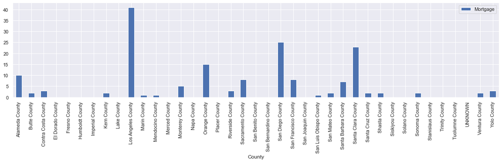

```python
loanMortgageDf[loanMortgageDf['Personal_Loan']==1].groupby(['County']).count().plot(kind='bar',y='Mortgage',figsize=(20,4));
```

**Observation**

- Only 480 customers took loan
- Only 168 customers has loan and mortgage
- In terms of Mortgage Top 5 counties are Los Angeles, San Diego, Santa clara, Orange and Alameda.

##### Correlation between columns.

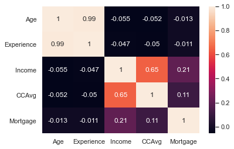

```python
sns.heatmap(df.corr(),annot=True, cbar=True);
```

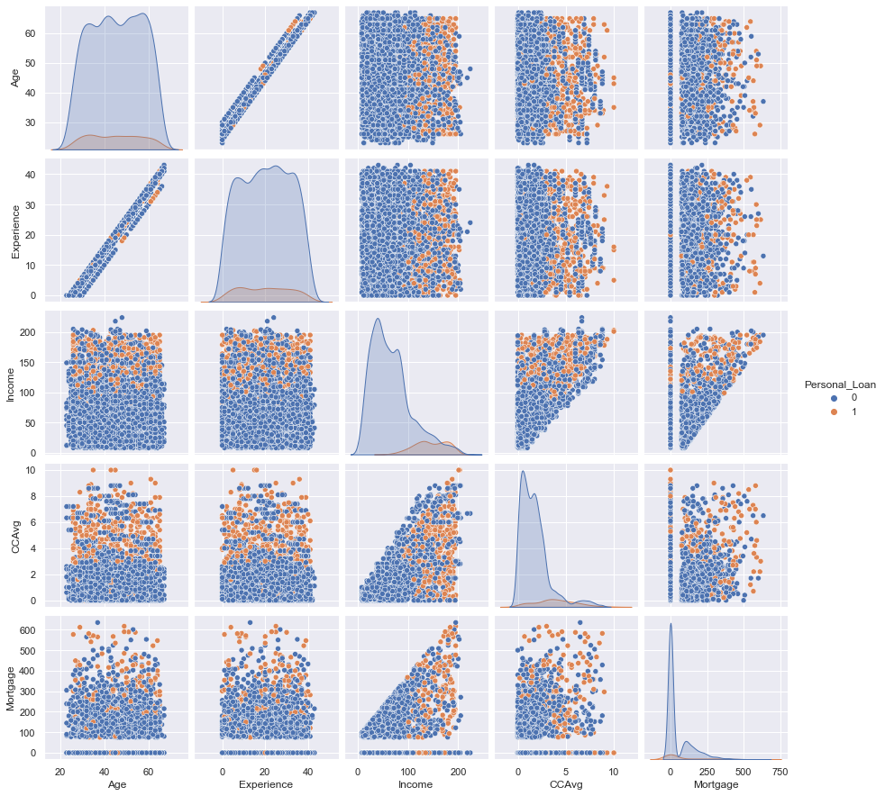

```python
sns.pairplot(df, hue="Personal_Loan")
```

**Observation**

```python
dfOriginalAfterPreProcessing.info()
```

```
<class 'pandas.core.frame.DataFrame'>
RangeIndex: 5000 entries, 0 to 4999
Data columns (total 14 columns):
 #   Column              Non-Null Count  Dtype
---  ------              --------------  -----
 0   Age                 5000 non-null   int64
 1   Experience          5000 non-null   int64
 2   Income              5000 non-null   int64
 3   ZIPCode             5000 non-null   int64
 4   Family              5000 non-null   int64
 5   CCAvg               5000 non-null   float64
 6   Education           5000 non-null   int64
 7   Mortgage            5000 non-null   int64
 8   Personal_Loan       5000 non-null   int64
 9   Securities_Account  5000 non-null   int64
 10  CD_Account          5000 non-null   int64
 11  Online              5000 non-null   int64
 12  CreditCard          5000 non-null   int64
 13  County              5000 non-null   object
dtypes: float64(1), int64(12), object(1)
memory usage: 547.0+ KB
```

#### Personal_Loan Vs "Family","Education","Mortgage", "Securities_Account", "CD_Account", "CreditCard", "Online" and "CCAvg"

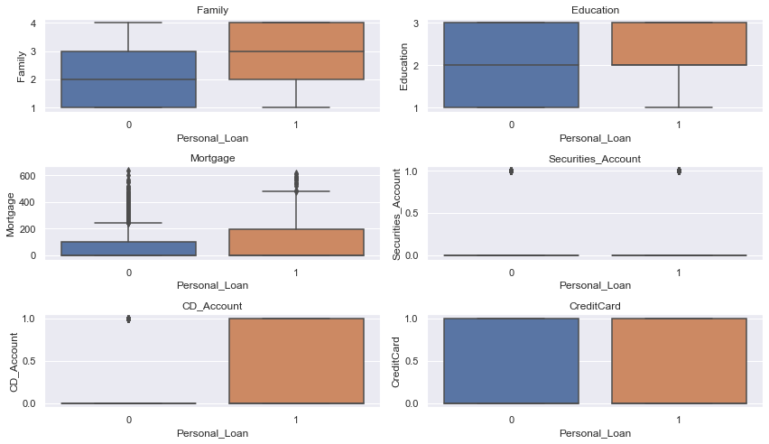

```python
cols = data[
    [
        "Family",
        "Education",
        "Mortgage",
        "Securities_Account",
        "CD_Account",
        "CreditCard",
    ]
].columns.tolist()
plt.figure(figsize=(12, 7))

for i, variable in enumerate(cols):
    plt.subplot(3, 2, i + 1)
    sns.boxplot(dfOriginalAfterPreProcessing["Personal_Loan"], dfOriginalAfterPreProcessing[variable])
    plt.tight_layout()
    plt.title(variable)
plt.show()
```

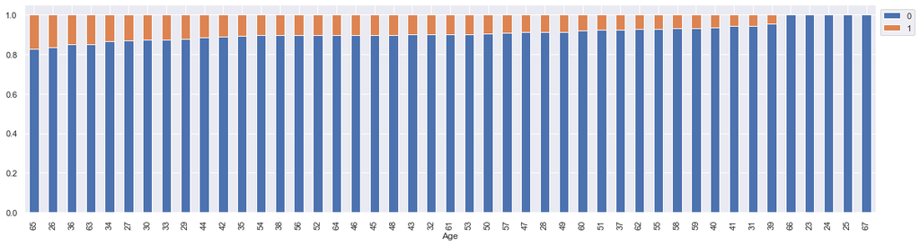

```python
stacked_barplot(df, "Age", "Personal_Loan");
```

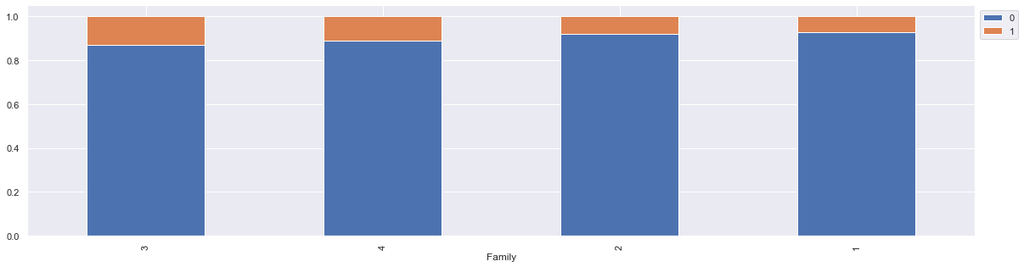

```python
stacked_barplot(df, "Family", "Personal_Loan");
```

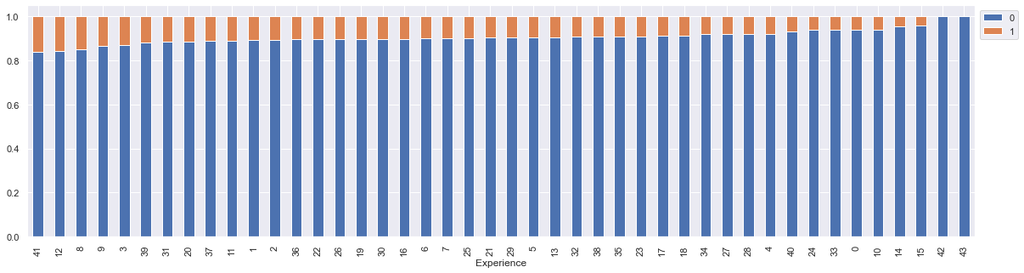

```python
stacked_barplot(df, "Experience", "Personal_Loan");
```

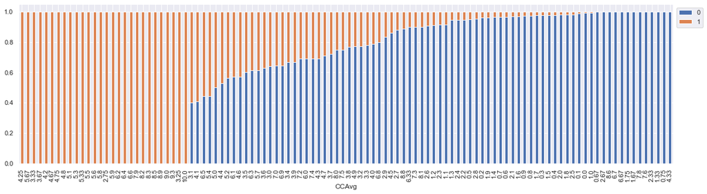

```python
stacked_barplot(df, "CCAvg", "Personal_Loan");
```

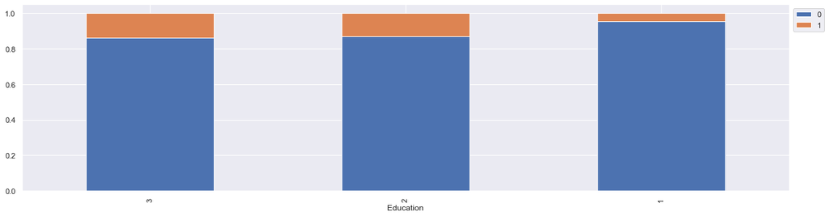

```python
stacked_barplot(df, "Education", "Personal_Loan");
```

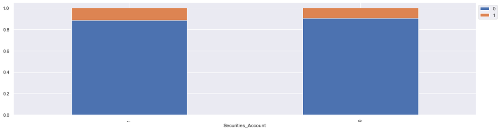

```python
stacked_barplot(df, "Securities_Account", "Personal_Loan");
```

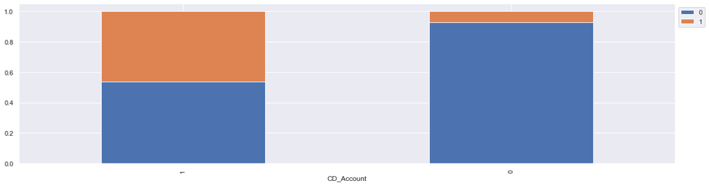

```python
stacked_barplot(df, "CD_Account", "Personal_Loan");
```

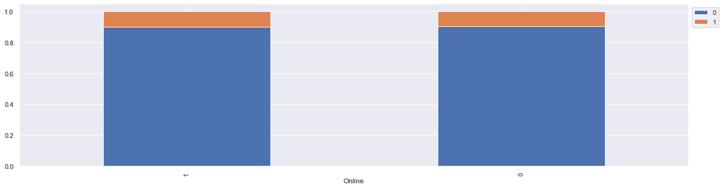

```python
stacked_barplot(df, "Online", "Personal_Loan");
```

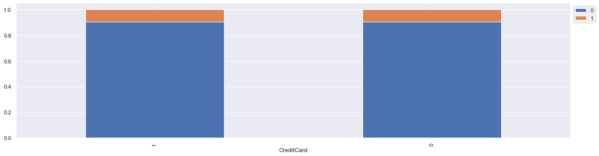

```python
stacked_barplot(df, "CreditCard", "Personal_Loan");
```

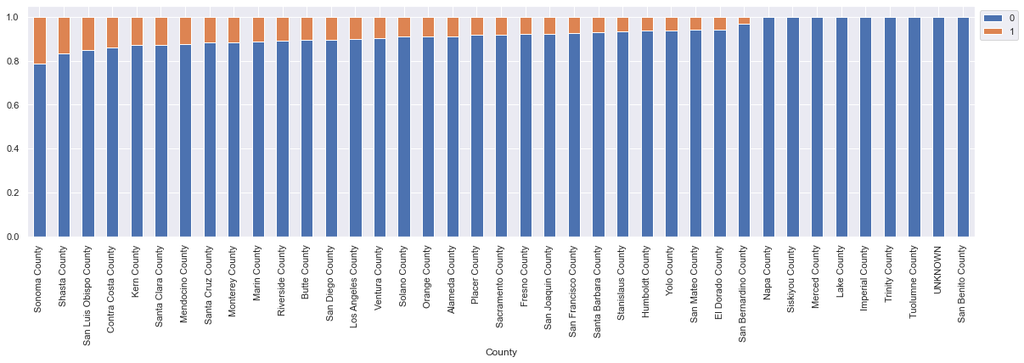

```python
stacked_barplot(df, "County", "Personal_Loan");
```

**Observation**

### Insights based on EDA

- Los Angeles Count has the highest percentage (23.12%) of Loan Santa clara (14.79%), San Diego (12.29%) and Alameda (9.17%) has the next three highest percentage of loans Other than Los Angeles,San Diego, Santa clara, Orange and Alameda counties the data is almost equally spreadover other counties
- In terms of Mortgage Top 5 counties are Los Angeles, San Diego, Santa clara, Orange and Alameda.
- Only 480 customers took loan and only 168 customers has both loan and mortgage
- Customers with higher income has taken personal loan and have more mortgage and CCAvg usage.
- Cusotmers with family size 3 has taken loan.
- Customers with Education (2 - Graduate) or above has taken loan
- Cusotmers with CD_Account (certificate of deposit) has taken loan
- Customers with higher CCAvg has taken loan

### Outlier Treatment

```python
## Handles outlier values
def outlierHandling(df,columnName):
    Q1=df[columnName].quantile(0.25) # 25th quantile
    Q3=df[columnName].quantile(0.75)  # 75th quantile
    IQR=Q3-Q1
    lowerWhisker = Q1 - 1.5*IQR
    upperWhisker = Q3 + 1.5*IQR

    # Assign lowerWhisker value to all the values lower than it
    # Assign upperWhisker value to all the values larger than it
    df[columnName] = np.clip(df[columnName], lowerWhisker, upperWhisker)
    return df
```

```python
#Copy the data frame
dfWithOutlierHandled=df.copy()
```

#### As per our analysis above - we have seen that Income, Mortgage, CCAvg has outliers, we need to handle outliers for these columns

```python
outlierHandling(dfWithOutlierHandled,'Income');
outlierHandling(dfWithOutlierHandled,'Mortgage');
outlierHandling(dfWithOutlierHandled,'CCAvg');
```

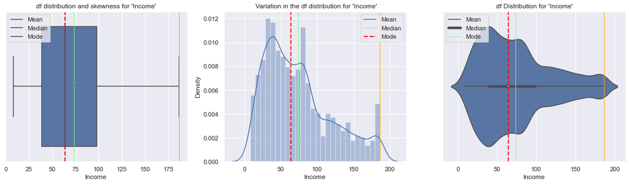

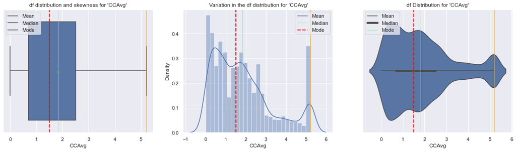

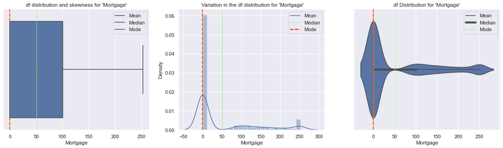

```python
drawGraph(dfWithOutlierHandled,'Income')
drawGraph(dfWithOutlierHandled,'CCAvg')
drawGraph(dfWithOutlierHandled,'Mortgage')
```

### Data Preparation

```python
#drop column which we don't need for modelling
dfWithOutlierHandled.drop(columns=["ZIPCode","County",'Experience'], inplace=True)
```

### Creating training and test sets.

```python
X = dfWithOutlierHandled.drop("Personal_Loan", axis=1)  # Features
y = dfWithOutlierHandled["Personal_Loan"]  # Labels (Target Variable)
```

```python
# Generate the dummies for Education column using One Hot Encoding
X=pd.get_dummies(X,columns=['Education'],drop_first=True)
```

```python
# Splitting data into training and test set:
X_train, X_test, y_train, y_test = train_test_split(X, y, test_size=0.3, random_state=1)
print(X_train.shape, X_test.shape)
```

```
(3500, 11) (1500, 11)
```

```python
print("Number of rows in train data =", X_train.shape[0])
print("Number of rows in test data =", X_test.shape[0])
```

```
Number of rows in train data = 3500
Number of rows in test data = 1500
```

```python
print("Percentage of classes in training set:")
print(y_train.value_counts(normalize=True))
print("Percentage of classes in test set:")
print(y_test.value_counts(normalize=True))
```

```
Percentage of classes in training set:
0    0.905429
1    0.094571
Name: Personal_Loan, dtype: float64
Percentage of classes in test set:
0    0.900667
1    0.099333
Name: Personal_Loan, dtype: float64
```

## Building the model

### Model can make wrong predictions as:

- Predicting a customer will take a loan but he actually doesn't take
- Predicting a customer will not take a loan but he actually does take

### Which case is more important?

- A loss of opportunity (ie. second case) - bank failed to make a customer take loan due to wrong prediction and the purpose of this campaign is to increase loan takes and hence we want to minimize loss of opportunity.

### How to reduce this loss i.e need to reduce False Negatives?

- recall should be maximized, the greater the recall lesser the chances of false negatives

#### Utility methods for classification

```python
# defining a function to compute different metrics to check performance of a classification model built using sklearn

def model_performance_classification_with_threshold(model, predictors, target, threshold=0.5):
    """
    Function to compute different metrics, based on the threshold specified, to check classification model performance

    model: classifier
    predictors: independent variables
    target: dependent variable
    threshold: threshold for classifying the observation as class 1
    """

    # predicting using the independent variables
    pred_prob = model.predict_proba(predictors)[:, 1]
    pred_thres = pred_prob > threshold
    pred = np.round(pred_thres)

    acc = accuracy_score(target, pred)  # to compute Accuracy
    recall = recall_score(target, pred)  # to compute Recall
    precision = precision_score(target, pred)  # to compute Precision
    f1 = f1_score(target, pred)  # to compute F1-score

    # creating a dataframe of metrics
    df_perf = pd.DataFrame(
        {
            "Accuracy": acc,
            "Recall": recall,
            "Precision": precision,
            "F1": f1,
        },
        index=[0],
    )

    return df_perf


# defining a function to plot the confusion_matrix of a classification model built using sklearn
def confusion_matrix_with_threshold(model, predictors, target, threshold=0.5):
    """
    To plot the confusion_matrix, based on the threshold specified, with percentages

    model: classifier
    predictors: independent variables
    target: dependent variable
    threshold: threshold for classifying the observation as class 1
    """
    pred_prob = model.predict_proba(predictors)[:, 1]
    pred_thres = pred_prob > threshold
    y_pred = np.round(pred_thres)

    cm = confusion_matrix(target, y_pred)
    labels = np.asarray(
        [
            ["{0:0.0f}".format(item) + "\n{0:.2%}".format(item / cm.flatten().sum())]
            for item in cm.flatten()
        ]
    ).reshape(2, 2)

    plt.figure(figsize=(6, 4))
    sns.heatmap(cm, annot=labels, fmt="")
    plt.ylabel("True label")
    plt.xlabel("Predicted label")
```

### Logistic Regression

```python
# There are different solvers available in Sklearn logistic regression
# The newton-cg solver is faster for high-dimensional data

lg = LogisticRegression(solver="newton-cg", random_state=1)
model = lg.fit(X_train, y_train)
```

#### Finding the coefficients

```python
# let us check the coefficients and intercept of the model
coef_df = pd.DataFrame(
    np.append(lg.coef_, lg.intercept_),
    index=X_train.columns.tolist() + ["Intercept"],
    columns=["Coefficients"],
)
coef_df.T
```

|  | Age | Income | Family | CCAvg | Mortgage | Securities_Account | CD_Account | Online | CreditCard | Education_2 | Education_3 | Intercept |
| --- | --- | --- | --- | --- | --- | --- | --- | --- | --- | --- | --- | --- |
| Coefficients | 0.007524 | 0.056589 | 0.682038 | 0.417548 | 0.001325 | -0.747352 | 3.043274 | -0.557656 | -0.824733 | 3.432099 | 3.525472 | -13.580526 |

#### Coefficient interpretations

- Coefficient of Securities_Account, Online and CreditCard are negative, increase in these will lead to decrease in chances of customer taking personal loan.
- Coefficient of Age, Income, Family, CCAvg, Education, Mortgage, CD_Account are positive increase in these will lead to increase in chances of a customer taking personal loan.

#### Odds from coefficients

```python
# converting coefficients to odds
odds = np.exp(lg.coef_[0])

# finding the percentage change
perc_change_odds = (np.exp(lg.coef_[0]) - 1) * 100

# removing limit from number of columns to display
pd.set_option("display.max_columns", None)

# adding the odds to a dataframe
pd.DataFrame({"Odds": odds, "Change_odd%": perc_change_odds}, index=X_train.columns).T
```

|  | Age | Income | Family | CCAvg | Mortgage | Securities_Account | CD_Account | Online | CreditCard | Education_2 | Education_3 |
| --- | --- | --- | --- | --- | --- | --- | --- | --- | --- | --- | --- |
| Odds | 1.007552 | 1.058220 | 1.977905 | 1.518234 | 1.001326 | 0.473619 | 20.973806 | 0.572549 | 0.438352 | 30.941507 | 33.969788 |
| Change_odd% | 0.755220 | 5.822027 | 97.790527 | 51.823396 | 0.132558 | -52.638077 | 1997.380622 | -42.745059 | -56.164812 | 2994.150686 | 3296.978832 |

#### Checking model performance on training set

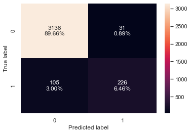

```python
# creating confusion matrix
confusion_matrix_with_threshold(lg, X_train, y_train)
```

```python
log_reg_model_train_perf = model_performance_classification_with_threshold(
    lg, X_train, y_train
)

print("Training performance:")
log_reg_model_train_perf
```

```
Training performance:
```

|  | Accuracy | Recall | Precision | F1 |
| --- | --- | --- | --- | --- |
| 0 | 0.961143 | 0.682779 | 0.879377 | 0.768707 |

#### Checking performance on test set

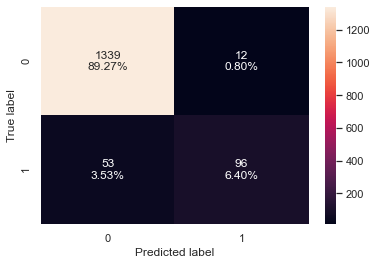

```python
# creating confusion matrix
confusion_matrix_with_threshold(lg, X_test, y_test)
```

```python
log_reg_model_test_perf = model_performance_classification_with_threshold(
    lg, X_test, y_test
)

print("Test set performance:")
log_reg_model_test_perf
```

```
Test set performance:
```

|  | Accuracy | Recall | Precision | F1 |
| --- | --- | --- | --- | --- |
| 0 | 0.956667 | 0.644295 | 0.888889 | 0.747082 |

#### ROC-AUC

##### ROC-AUC on training set

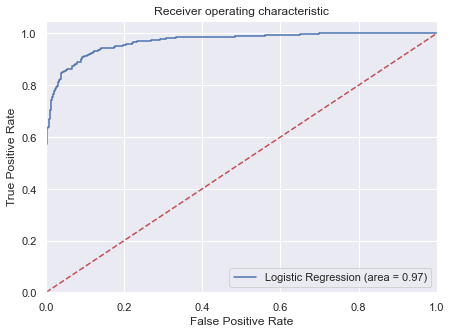

```python
logit_roc_auc_train = roc_auc_score(y_train, lg.predict_proba(X_train)[:, 1])
fpr, tpr, thresholds = roc_curve(y_train, lg.predict_proba(X_train)[:, 1])
plt.figure(figsize=(7, 5))
plt.plot(fpr, tpr, label="Logistic Regression (area = %0.2f)" % logit_roc_auc_train)
plt.plot([0, 1], [0, 1], "r--")
plt.xlim([0.0, 1.0])
plt.ylim([0.0, 1.05])
plt.xlabel("False Positive Rate")
plt.ylabel("True Positive Rate")
plt.title("Receiver operating characteristic")
plt.legend(loc="lower right")
plt.show()
```

##### ROC-AUC on test set

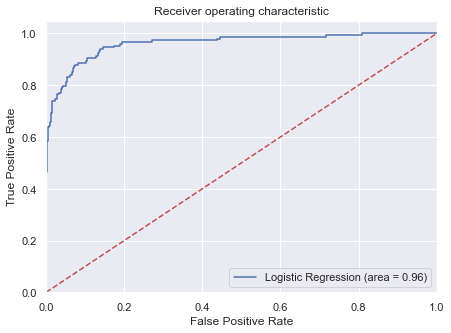

```python
logit_roc_auc_test = roc_auc_score(y_test, lg.predict_proba(X_test)[:, 1])
fpr, tpr, thresholds = roc_curve(y_test, lg.predict_proba(X_test)[:, 1])
plt.figure(figsize=(7, 5))
plt.plot(fpr, tpr, label="Logistic Regression (area = %0.2f)" % logit_roc_auc_test)
plt.plot([0, 1], [0, 1], "r--")
plt.xlim([0.0, 1.0])
plt.ylim([0.0, 1.05])
plt.xlabel("False Positive Rate")
plt.ylabel("True Positive Rate")
plt.title("Receiver operating characteristic")
plt.legend(loc="lower right")
plt.show()
```

##### Model Performance Improvement

- Let's see if the recall score can be improved, by changing the model threshold using AUC-ROC Curve.

#### Optimal threshold using AUC-ROC curve¶

```python
# Optimal threshold as per AUC-ROC curve
# The optimal cut off would be where tpr is high and fpr is low
fpr, tpr, thresholds = roc_curve(y_train, lg.predict_proba(X_train)[:, 1])

optimal_idx = np.argmax(tpr - fpr)
optimal_threshold_auc_roc = thresholds[optimal_idx]
print(optimal_threshold_auc_roc)
```

```
0.10168071815763399
```

#### Checking model performance on training set

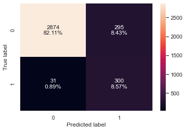

```python
# creating confusion matrix
confusion_matrix_with_threshold(
    lg, X_train, y_train, threshold=optimal_threshold_auc_roc
)
```

```python
# checking model performance for this model
log_reg_model_train_perf_threshold_auc_roc = model_performance_classification_with_threshold(
    lg, X_train, y_train, threshold=optimal_threshold_auc_roc
)
print("Training performance:")
log_reg_model_train_perf_threshold_auc_roc
```

```
Training performance:
```

|  | Accuracy | Recall | Precision | F1 |
| --- | --- | --- | --- | --- |
| 0 | 0.906857 | 0.906344 | 0.504202 | 0.647948 |

#### Checking model performance on test set

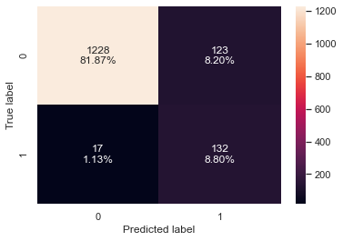

```python
# creating confusion matrix
confusion_matrix_with_threshold(
    lg, X_test, y_test, threshold=optimal_threshold_auc_roc
)
```

```python
# checking model performance for this model
log_reg_model_test_perf_threshold_auc_roc = model_performance_classification_with_threshold(
    lg, X_test, y_test, threshold=optimal_threshold_auc_roc
)
print("Test set performance:")
log_reg_model_test_perf_threshold_auc_roc
```

```
Test set performance:
```

|  | Accuracy | Recall | Precision | F1 |
| --- | --- | --- | --- | --- |
| 0 | 0.906667 | 0.885906 | 0.517647 | 0.653465 |

**Observation**

- The precision of the model is just 51% and training & test set has improved but the recall score.

#### Let's use Precision-Recall curve and see if we can find a better threshold

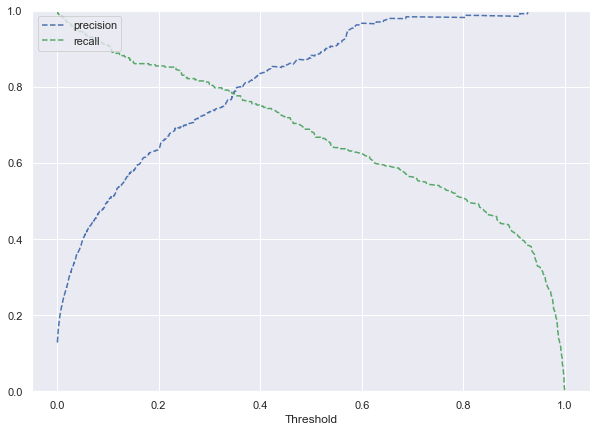

```python
y_scores = lg.predict_proba(X_train)[:, 1]
prec, rec, tre = precision_recall_curve(y_train, y_scores,)


def plot_prec_recall_vs_tresh(precisions, recalls, thresholds):
    plt.plot(thresholds, precisions[:-1], "b--", label="precision")
    plt.plot(thresholds, recalls[:-1], "g--", label="recall")
    plt.xlabel("Threshold")
    plt.legend(loc="upper left")
    plt.ylim([0, 1])


plt.figure(figsize=(10, 7))
plot_prec_recall_vs_tresh(prec, rec, tre)
plt.show()
```

**Observation**

- At the threshold of 0.35, we get balanced recall and precision.

```python
# setting the threshold
optimal_threshold_curve = 0.35
```

#### Checking model performance on training set

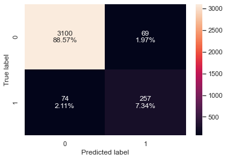

```python
# creating confusion matrix
confusion_matrix_with_threshold(
    lg, X_train, y_train, threshold=optimal_threshold_curve
)
```

```python
log_reg_model_train_perf_threshold_curve = model_performance_classification_with_threshold(
    lg, X_train, y_train, threshold=optimal_threshold_curve
)
print("Training performance:")
log_reg_model_train_perf_threshold_curve
```

```
Training performance:
```

|  | Accuracy | Recall | Precision | F1 |
| --- | --- | --- | --- | --- |
| 0 | 0.959143 | 0.776435 | 0.788344 | 0.782344 |

#### Checking model performance on test set

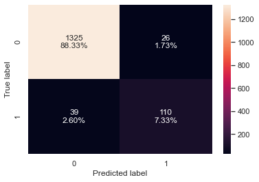

```python
# creating confusion matrix
confusion_matrix_with_threshold(
    lg, X_test, y_test, threshold=optimal_threshold_curve
)
```

```python
log_reg_model_test_perf_threshold_curve = model_performance_classification_with_threshold(
    lg, X_test, y_test, threshold=optimal_threshold_curve
)
print("Test set performance:")
log_reg_model_test_perf_threshold_curve
```

```
Test set performance:
```

|  | Accuracy | Recall | Precision | F1 |
| --- | --- | --- | --- | --- |
| 0 | 0.956667 | 0.738255 | 0.808824 | 0.77193 |

**Observation**

- Model is performing well on training and test.
- At 0.35 as the optimal threshold we getting better recall and precision